# Activity Monitoring Report

Vinod M

Tuesday, April 14, 2015

## Loading and preprocessing the data :

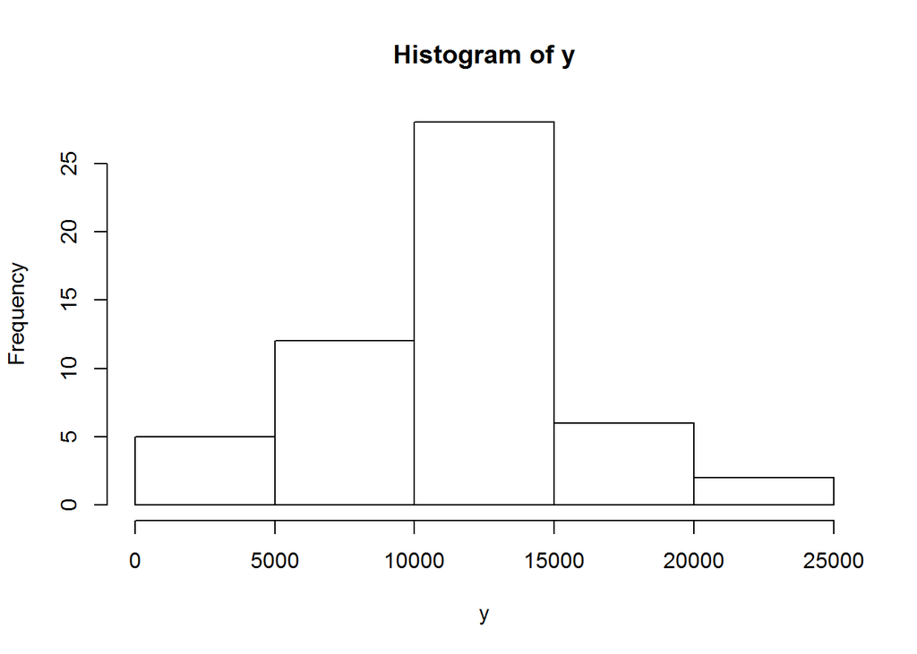

```r
data <- read.csv("C:/RLearning/RepResearch/activity.csv")
x <- data
x[,'date'] <- as.factor(x[,'date'])
y <- tapply(x$steps,x$date,sum)
hist(y)
```

The mean of steps taken per day is 10766.2 and median is:10765

## Average daily activity pattern

A time series plotof the 5-minute interval (x-axis) and the average number of steps taken, averaged across all days (y-axis) is shown below:

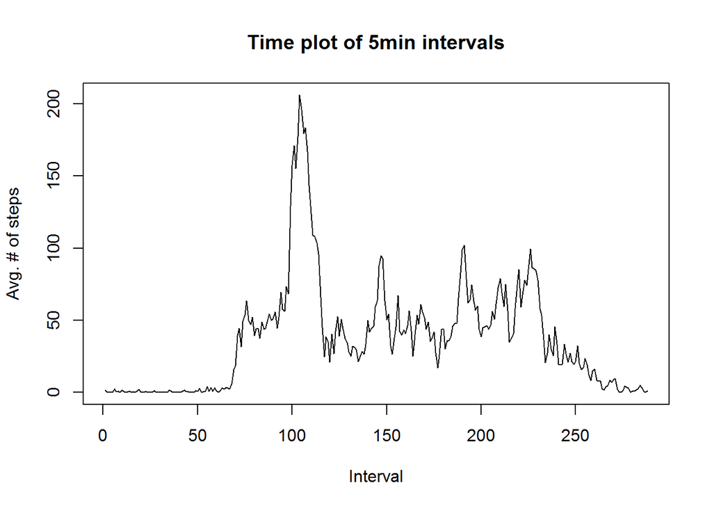

```r
x <- data
x$interval <- as.factor(x$interval)
y <- tapply(x$steps,x$interval,mean,na.rm=TRUE)
 plot(y,type="l",xlab="Interval",ylab="Avg. # of steps",main="Time plot of 5min intervals")
```

The max average steps occur in the 104 interval

## Imputing missing values

Some values in the original dataset are missing the number of steps for some intervals. The total number of missing values are 2304 These values are imputed by using the average value for the interval (calculated above) accross all days

```r
y <- data.frame(y)
for(i in 1:nrow(x))
{if(is.na(x[i,1])){x[i,1] <- y[x[i,3],]}}
```

Here is a snapshot of the dataset containing the imputed values:

```r
head(x,10)
```

```
##        steps       date interval
## 1  1.7169811 2012-10-01        0
## 2  0.3396226 2012-10-01        5
## 3  0.1320755 2012-10-01       10
## 4  0.1509434 2012-10-01       15
## 5  0.0754717 2012-10-01       20
## 6  2.0943396 2012-10-01       25
## 7  0.5283019 2012-10-01       30
## 8  0.8679245 2012-10-01       35
## 9  0.0000000 2012-10-01       40
## 10 1.4716981 2012-10-01       45
```

A histogram of the total number of steps taken each day is below:

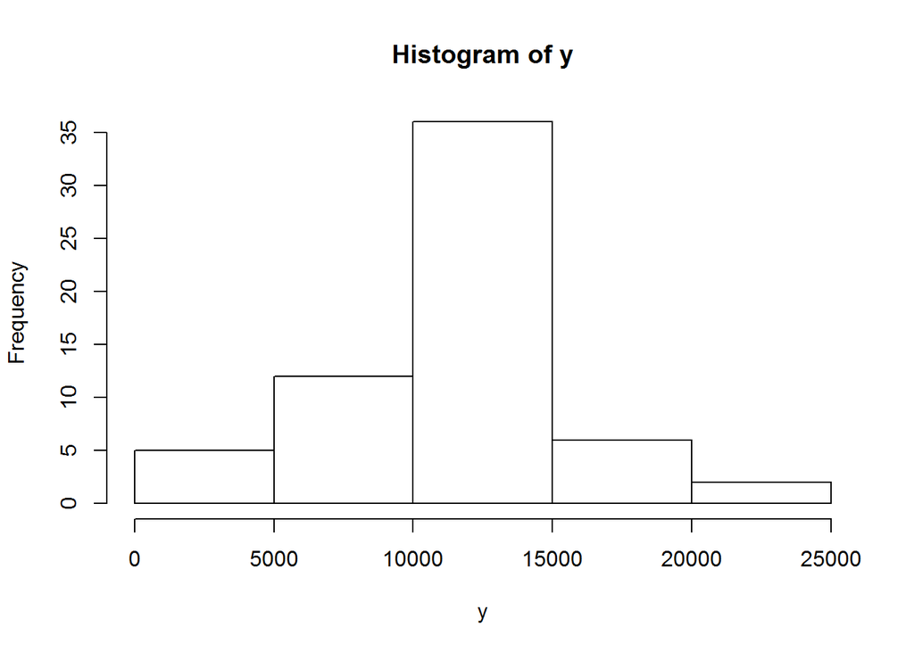

```r
x[,'date'] <- as.factor(x[,'date'])
y <- tapply(x$steps,x$date,sum)
hist(y)
```

## Differences in activity patterns between weekdays and weekends?

To infer the differences between weekday and weekend activity, the data is seperated using factors weekday and weekend using a new column (called status) using the R weekdays function applied on the activity date

```r
x$date = as.Date(x$date)
y <- weekdays(x$date)
x$status <- ""
for(i in 1:nrow(x))
{if(y[i] =="Saturday" | y[i]=="Sunday"){x[i,"status"] <- "weekend"}else{x[i,"status"] <- "weekday"} }
xx <- list(x$interval,x$status)
y <- tapply(x$steps,xx,sum)
```

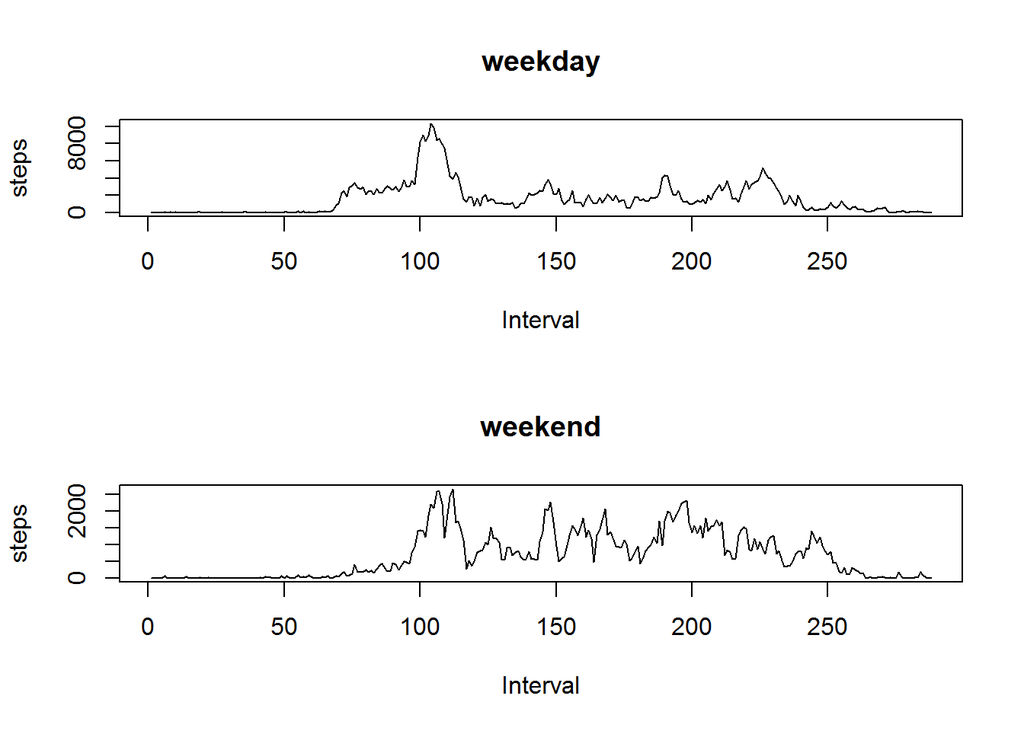

```r
par(mfrow=(c(2,1)))
plot(y[,1],type="l",xlab="Interval",ylab="steps",main="weekday")
plot(y[,2],type="l",xlab="Interval",ylab="steps",main="weekend")
```